# Advanced SQL

Mirko Mälicke

```
 [1] "track_points"                 "celso_precipitation"          "stations"
 [4] "vegetation_cover_description" "vegetation_cover"             "einzugsgebiete"
 [7] "landuse"                      "stream"                       "bw_temp_2017b"
[10] "matthias_precipitation"       "spatial_ref_sys"              "variables"
[13] "only_dwd_stations"            "disciplines"                  "marvin_precipitation3"
[16] "data"                         "celso_precipitation"          "felix_precipitation"
[19] "hobo_indices"                 "stations"                     "exercice_logs"
[22] "precipitation"                "matthias_precipitation"
```

Build a temporary table called *name_precipitation*, where you should replace *name* with your actual name. This table shall contain all measurements from the data table holding precipitation information.

```
Fehler in postgresqlFetch(res, n, ...) :
  RS-DBI driver: (resultSet does not correspond to a SELECT statement)
Failed to execute SQL chunk
```

Create a view on this table that holds monthly statistics for every station id. Calculate the monthly sum, the highest observed daily rainfall sum, the number of extreme rainfalls (daily precipitation > 30).

Create a view on the last view, that aggregates the same statistics for anual overviews.

Which station observed the highest monthly rainfall sum?

| id | name | highest monthly rainfall |
| --- | --- | --- |
| 1346 | Feldberg_Schwarzwald | 2517.6 |

Which station observed the most extreme rainfall occurences within one month? Which within one year?

| id | name | extreme monthly rainfall occurence |
| --- | --- | --- |
| 1468 | Freudenstadt | 8 |

| id | name | extreme annual rainfall occurence |
| --- | --- | --- |
| 1468 | Freudenstadt | 21 |

Which was the year with the most overall extreme rainfall occurences? (ignoring the station)

| year | extreme rainfall occurences |
| --- | --- |
| 1982-01-01 | 117 |

Which is the station with the most extreme rainfall events within this year (from the last chunk)? Which one with the most extreme rainfall events overall?

| year | id | name | extreme rainfall days |
| --- | --- | --- | --- |
| 1982-01-01 | 1346 | Feldberg_Schwarzwald | 17 |

| id | name | overall extreme rainfall days |
| --- | --- | --- |
| 1346 | Feldberg_Schwarzwald | 626 |

Create a view, that includes only the records from *data* which fulfilled the extreme rainfall constraint. Join another column to this view, that holds the *type of precipitation* variable. From this Join, create a histogram of *type of precipitation*. Calculate an overall histogram.

```
Fehler in postgresqlFetch(res, n, ...) :
  RS-DBI driver: (resultSet does not correspond to a SELECT statement)
Failed to execute SQL chunk
```

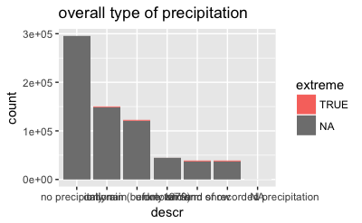

**OPTIONAL:** Can you redo the last step and do the same analysis for ‘per station’ histograms?

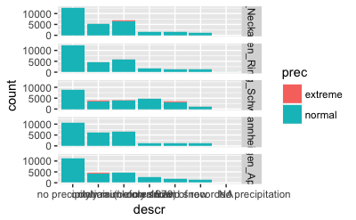

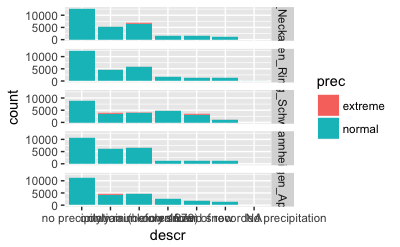

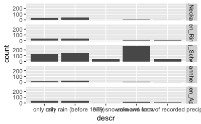

```r
ggplot(Part1, aes(descr, fill=prec) ) + geom_bar() + facet_grid(name ~ .)
ggplot(Part1, aes(descr, fill=prec) ) + geom_bar() + facet_grid(name ~ .)

Part1_extreme <- subset(Part1, prec == "extreme")
ggplot(Part1_extreme, aes(descr)) + geom_bar()  + facet_grid(name ~ .)
```

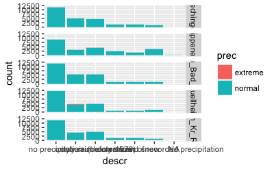

```r
part2 <- unique(overall_stations$name)[6:10]
Part2 <- subset(overall_stations, name %in% part2)
ggplot(Part2, aes(descr, fill=prec) ) + geom_bar() + facet_grid(name ~ .)
```

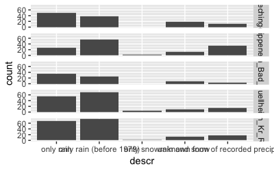

```r
Part2_extreme <- subset(Part2, prec == "extreme")
ggplot(Part2_extreme, aes(descr)) + geom_bar()  + facet_grid(name ~ .)
```

Use the insights of the last two chunks and write two sentences about the *type of precipitation* variable. How useful is it?

Answer: The type of precipitation only discriminates between the two types rain and snow. Those two types mostly depend on the temperature, and will not influence the amount of precipitation. Because most extreme rainfalls occur in summer and snow is rare at the most stations all over the year, the result doesn’t realy show any informations.

Load the anual overview on extreme rainfalls into a data.frame and plot a violine plot of the amount of extreme rainfalls per station.

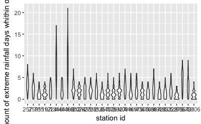

```r
#View(rain.annual)
ggplot(rain.annual, aes(factor(id), `extreme rainfall days`)) +
  geom_violin() + xlab("station id") + ylab("amount of extreme rainfall days whithin one year")
```

Redo the last exercise for the monthly extreme rainfall counts. Does this change the picture? What can you say about the distribution of extreme rainfall events from these plots?

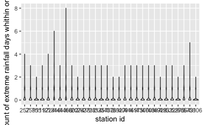

```r
#View(rain.monthly)
ggplot(rain.monthly, aes(factor(id), `extreme rainfall days`)) +
  geom_violin() + xlab("station id") + ylab("amount of extreme rainfall days whithin one month")
```

```r
head(rain.monthly)
```

|  | id | month | summe | maxi | extreme rainfall days |
| --- | --- | --- | --- | --- | --- |
| 1 | 257 | 1949-01-01 | 77.4 | 26.5 | 0 |
| 2 | 257 | 1949-02-01 | 35.3 | 9.3 | 0 |
| 3 | 257 | 1949-03-01 | 40.9 | 10.8 | 0 |
| 4 | 257 | 1949-04-01 | 71.5 | 12.2 | 0 |
| 5 | 257 | 1949-05-01 | 94.4 | 15.3 | 0 |
| 6 | 257 | 1949-06-01 | 33.3 | 17.5 | 0 |

Answer: The plots are different. The amount of extreme rainfall days within one year is in average at least two times as high as the amount within one month. This means that the extreme rainfall events of the year never occured all in one month, even not in a two months time. I would state from this pictures, that the extreme rainfall events are distributet normal over the year.

Load the locations for the used stations from the database.

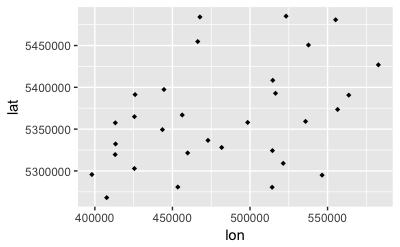

```r
View(locations)
ggplot(locations, aes(x=lon, y=lat)) + geom_point(shape=18)
```

Plot these locations and represent any measure for annual variance in extreme rainfall events by the point size of the used locations.  
**OPTIONAL:** Additionally mark the station showing the most and least recorded extreme rainfalls by another marker into the same plot. (eg. use a green and a red cross or star.)

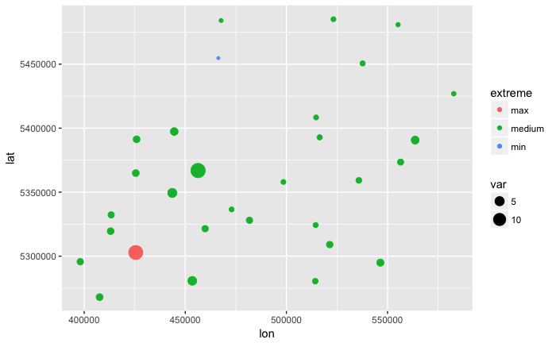

How can you interpret this result?

Answer: The stations with big variance in extreme rainfall events have had some years with many events and some with few. They therefore have a heterogenity over the years. The stations with little variance are affected by the extreme rainfall events mostly in the same amount, and as the colors show, have only had few rainfall events at all. Probably lots of extreme rainfall events are rare, but sometimes they occur. The rare occurence of years with lots of extreme rainfall events makes up the high variance. One might therefore expect a correlation between an increasing variance of yearly extreme rainfall events and the increasing overall amount of extreme rainfall events.